# Percolation threshold demo

**Percolation threshold** focuses on the formation of long-range connectivity in random systems. A giant component exists if and only if the percolation threshold is exceeded. For social network analysis, percolation threshold tells how many edges (or the average degree per node) a network should have before a giant component appears.

The following graphs show three random graphs each with 1,000 nodes. The average degree per node is at 0.98, 1.18, and 2.68, respectively. It confirms that the giant component appears when the average degree increases to 1.

Percolation threshold is a useful notion in social network analysis. For example, think about this question: how many other friends besides you does each of your friends have? When the average degree of your friends is 1, each of your friends is expected to have another friend, who in turn has another friend, so on and so forth. Therefore the giant component emerges.

```r
library(igraph)
library(ggplot2)
```

```r
get.random.graph <- function(numNodes, avgDegree) {
  return (random.graph.game(numNodes, numNodes * avgDegree / 2, type="gnm"))
}

get.fraction.giant.Component <- function(numNodes, avgDegree) {
  g <- get.random.graph(numNodes, avgDegree)
  if(toString(avgDegree) %in% c("0.98","1.18","2.68")) {
    plot(g, layout=layout.fruchterman.reingold, vertex.size=1, vertex.label=NA)
    title(paste0("Average degree: ", avgDegree))
  }
  return(max(clusters(g)$csize) / numNodes)
}
```

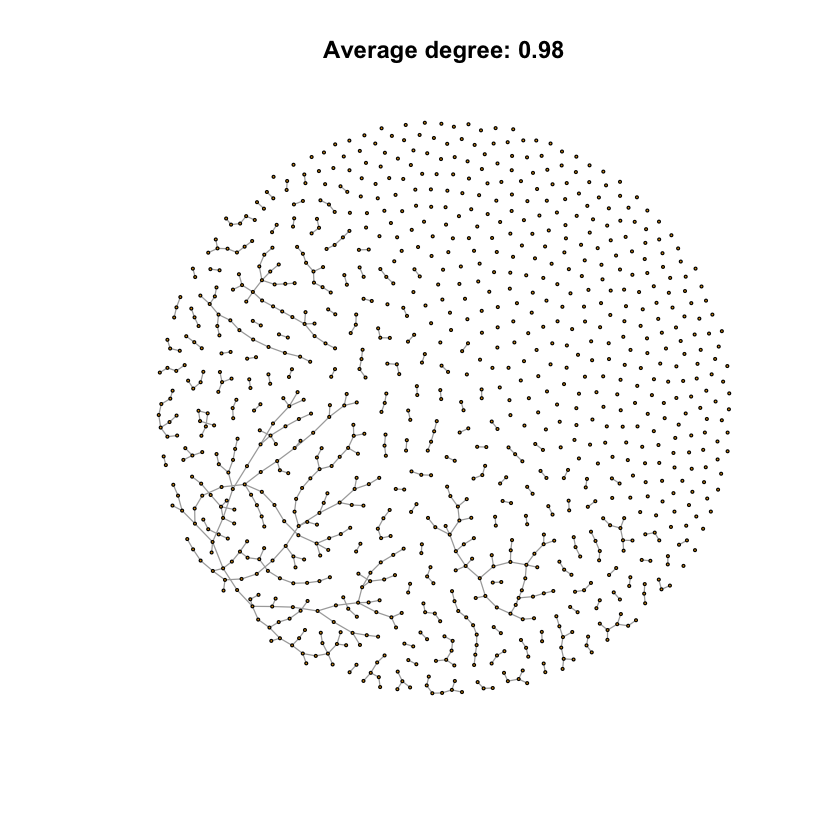

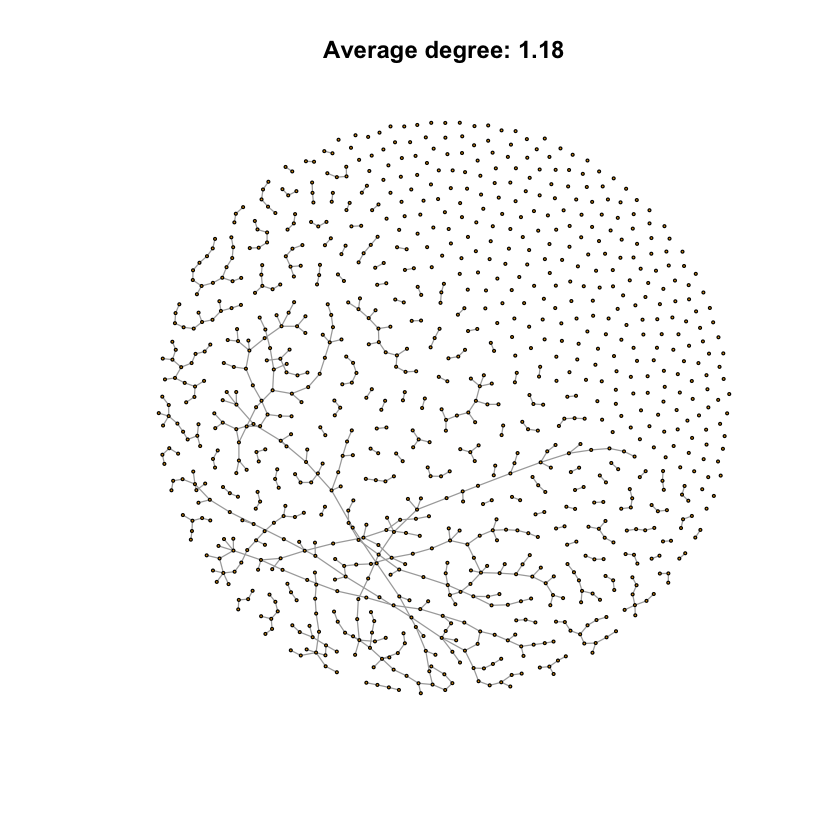

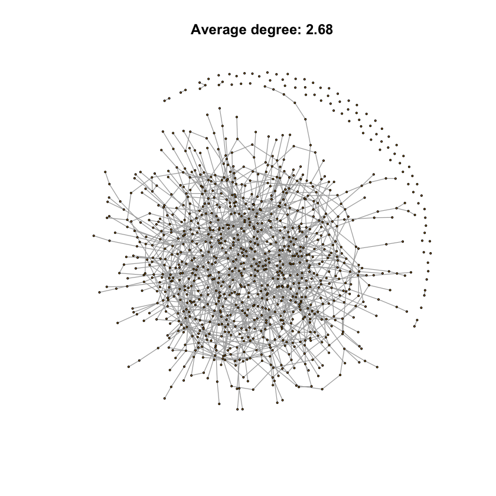

```r
stopAvgDegrees <- 8    # the no. degree to stop the iteration
numNodes <- 1000         # no. of nodes
avgDegrees <- seq(0, stopAvgDegrees, by=0.01)

fracGiantComponent <- rep(NA, length(avgDegrees))

for (i in 1:length(avgDegrees)) {
  fracGiantComponent[i] <- get.fraction.giant.Component(numNodes, avgDegrees[i])
}
```

The following plot shows the fraction of the giant component in a random graph in relation to the average degree per node. As the average degree increases to 1, a giant component suddenly appears.

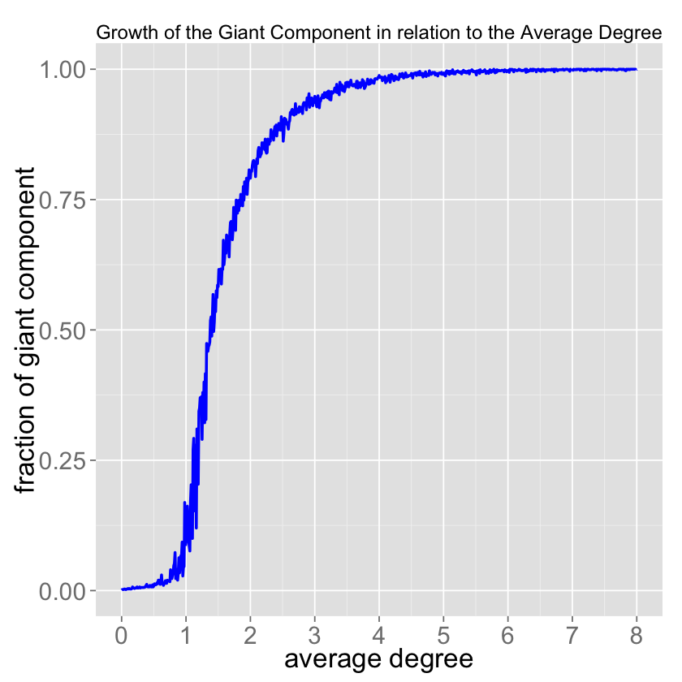

```r
df <- as.data.frame(cbind(avgDegrees,fracGiantComponent))

ggplot(df, aes(x=avgDegrees, y=fracGiantComponent)) +
  geom_line(colour = "blue", size = 1) +
  xlab("average degree") +
  ylab("fraction of giant component") +
  scale_x_continuous(breaks=0:8) +
  ggtitle("Growth of the Giant Component in relation to the Average Degree") +
  theme(axis.text=element_text(size=18),
        axis.title = element_text(size=20)
        )
```